# Hub messaging: show the operator the supervisor's turns, not the pane

### A · Ledger — the conversation as a ruled timeline

The thread is an annotated timeline: mono timestamps on a left spine, elapsed time printed under them, a kind eyebrow on every supervisor turn, the operator's directives inset as today. The one unanswered ask is the only indigo element and stays at the foot of the thread until a directive answers it. Statuses coalesce into one row; the working line sits above the composer; `Pane ▸` opens the emulator beside the thread on desktop and as a sheet on the phone. **Shell:** hub-mobile *04 · Supervisor conversations* — thread list, then a full-width thread with an addressed composer; on desktop the list, the thread and a context rail. **Protocol beyond the shared `kind` field:** none; coalescing and pinning are client-side.

A · Ledger · thread The thread: directive, answer, receipt, coalesced statuses, question, answer, blocker, the pinned ask, the working line.

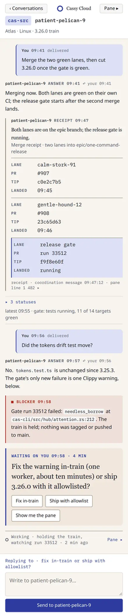

Mobile · 390 · light

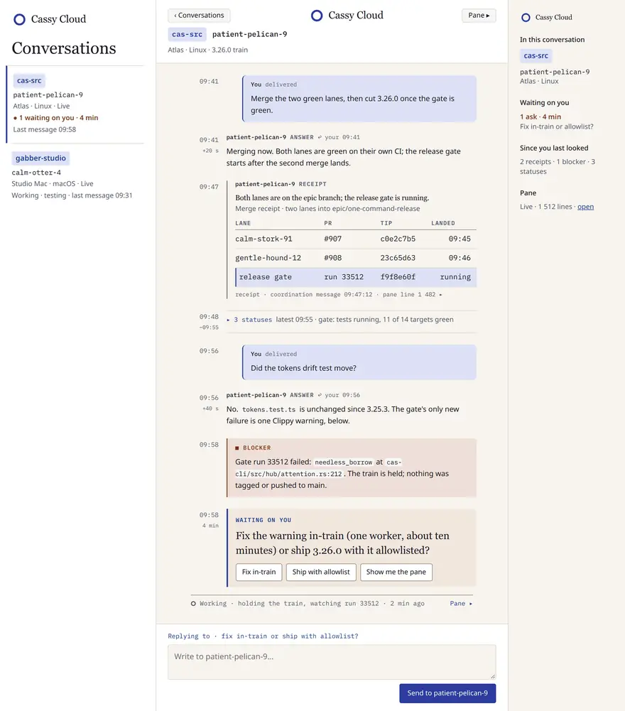

Desktop · 1280 · light

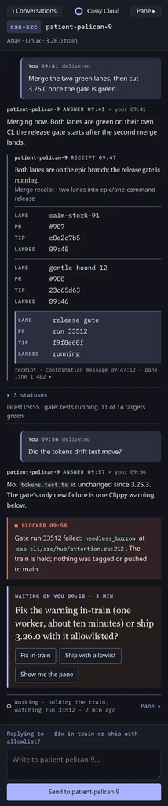

Mobile · 390 · dark

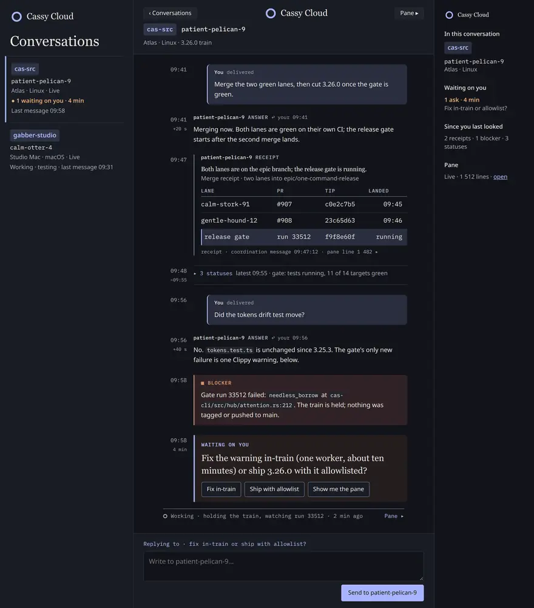

Desktop · 1280 · dark

A · Ledger · evidence Evidence and the escape hatch: the worker table inline with the pane open beside the thread on desktop; the same table as a full-width sheet on the phone.

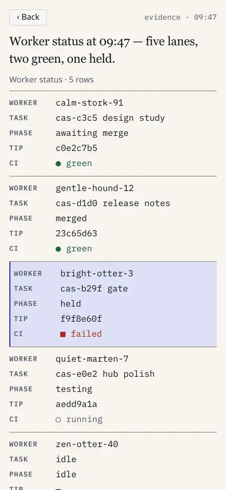

Mobile · 390 · light

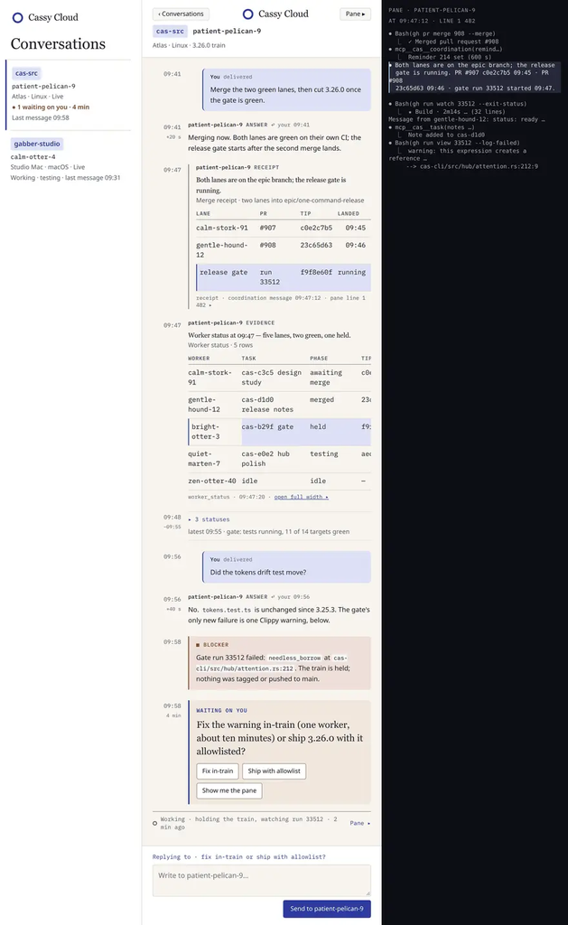

Desktop · 1280 · light

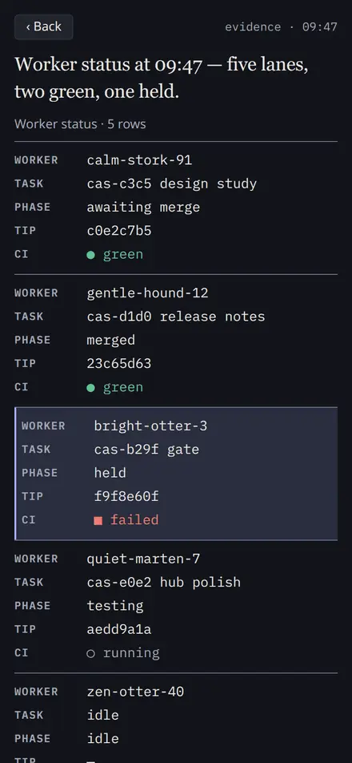

Mobile · 390 · dark

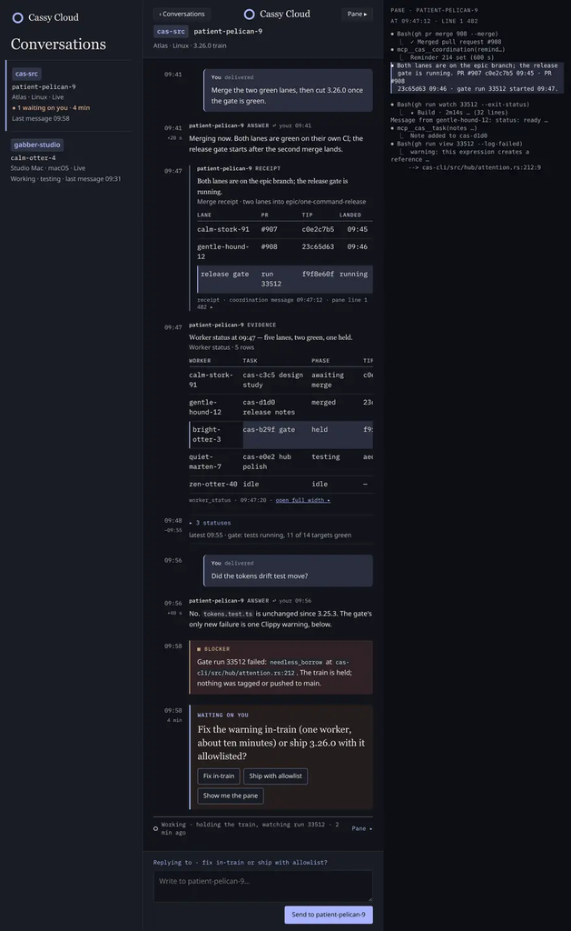

Desktop · 1280 · dark

### B · Desk — a queue of what needs you

[figure not shown]

Mobile · 390 · light

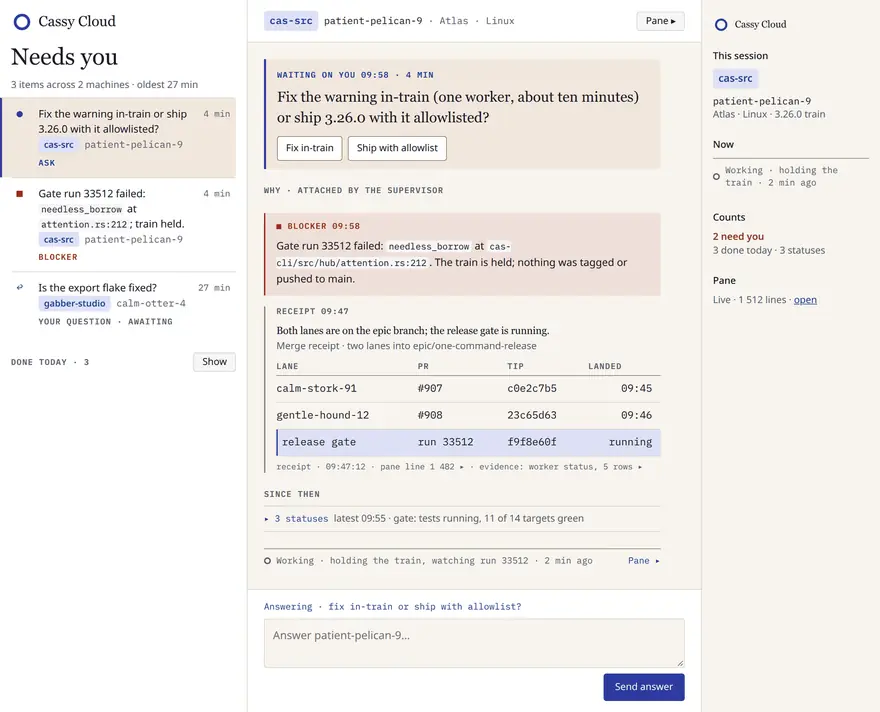

Desktop · 1280 · light

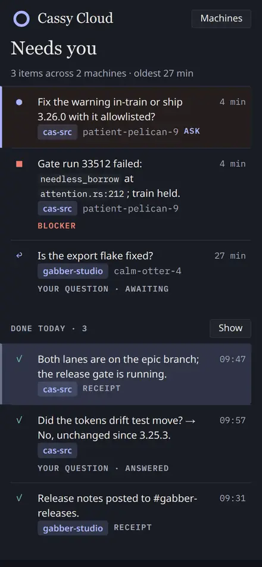

Mobile · 390 · dark

[figure not shown]

Desktop · 1280 · dark

B · Desk · item Done items: a receipt opened from the Done list with the directive that led to it and its evidence table; on the phone, the ask page with its answer box.

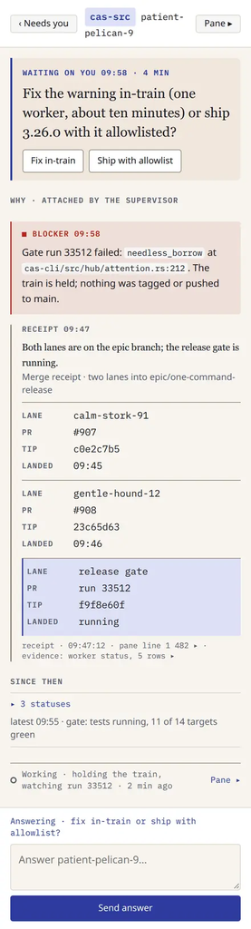

Mobile · 390 · light

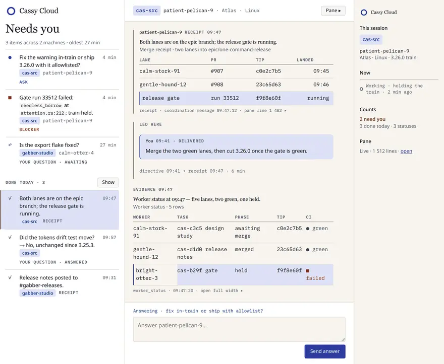

Desktop · 1280 · light

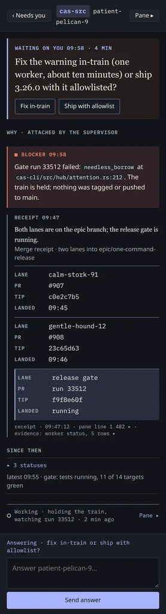

Mobile · 390 · dark

[figure not shown]

Desktop · 1280 · dark

### C · Brief — a page the supervisor keeps current

One page per session — Now, Decisions needed, Outcomes, Answers, Status — where each new statement of a kind replaces the previous one. The operator's directives are margin notes on desktop and inline notes on the phone, each pointing at the section it changed; `Earlier ▾` opens the drawer of replaced statements, struck through. **Shell:** hub-mobile *05 · The daily brief* — a dated reading page with decisions, changes and evidence links; on desktop the brief beside its source. **Protocol beyond `kind`:** replace semantics — a `supersedes` field (or one slot per kind per session) so a new status or working statement retires the last one durably; receipts and answers accumulate; asks close as in Desk.

C · Brief · now The page: Now, Decisions needed, Outcomes since 09:30, Answers, Status — with your directives as margin notes on desktop and inline notes on the phone; the live phone composer stays pinned to the bottom edge.

[figure not shown]

Mobile · 390 · light

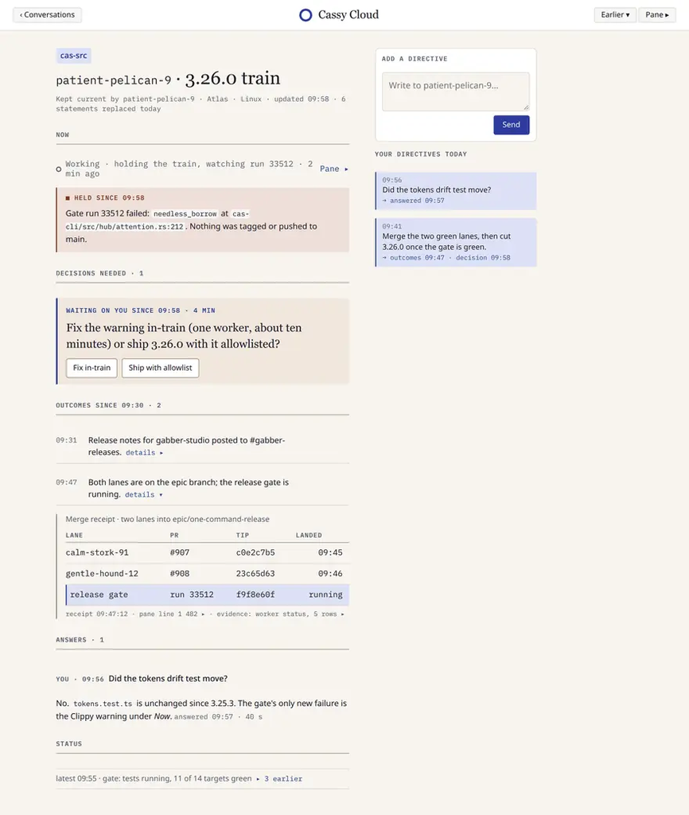

Desktop · 1280 · light

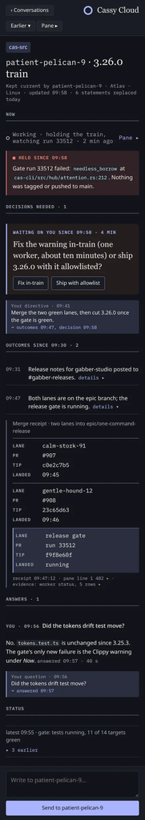

Mobile · 390 · dark

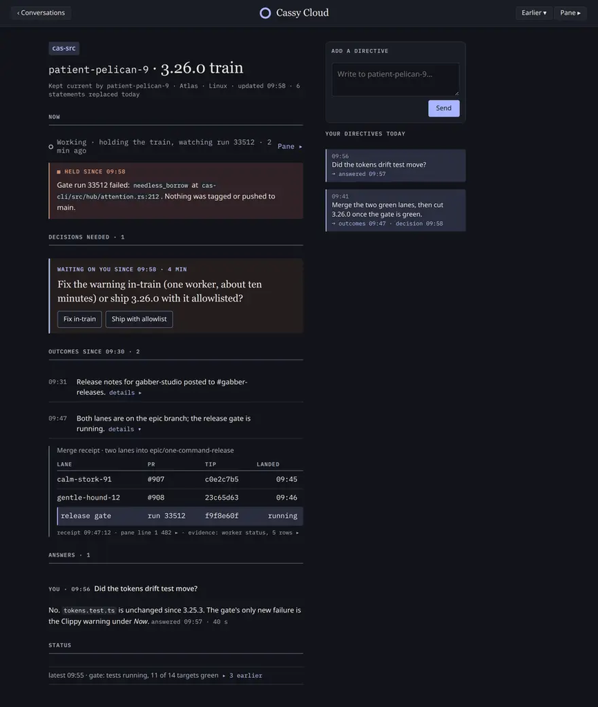

Desktop · 1280 · dark

C · Brief · history Earlier: what the page said before, with replaced statements struck through and kept ones plain.

[figure not shown]

Mobile · 390 · light

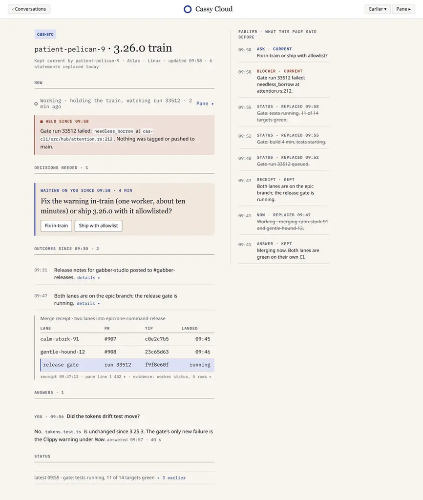

Desktop · 1280 · light

[figure not shown]

Mobile · 390 · dark

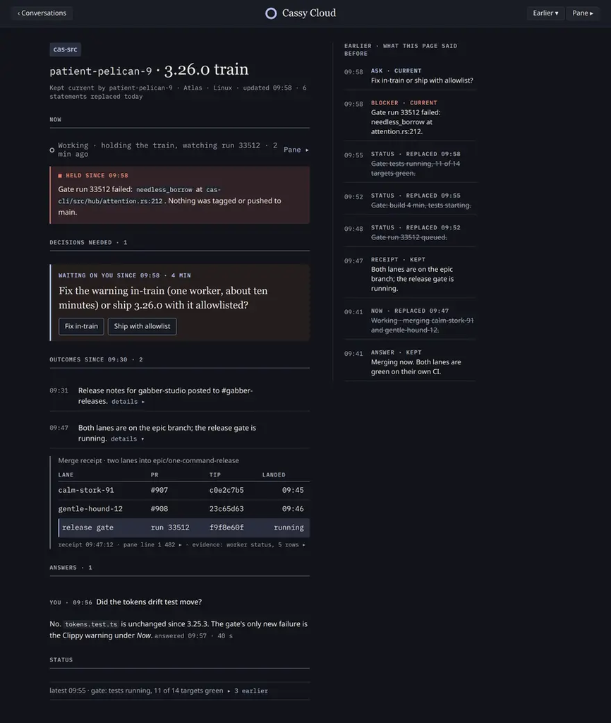

Desktop · 1280 · dark

### Choosing

The three options against the questions an operator opens the hub with. The recommended row is banded in the HTML.

| Option | The first screen answers | History | On a phone | Protocol delta | Cost of being wrong |
| --- | --- | --- | --- | --- | --- |
| **A · Ledger** | *what did the supervisor say to me, in order?* | complete, in place, elapsed times printed | a familiar thread; ledgers stack | one field: `kind` | low — it degrades to today's thread |
| B · Desk | *what needs me right now?* | in Done, per item | a list, then one item | `kind` + a durable ask lifecycle + cross-machine aggregation | medium — an item model that drifts from the pane misleads |
| C · Brief | *what is true right now?* | in a drawer, struck through | one reading page | `kind` + replace semantics held server-side | high — a latest-state page hides how a decision was reached |

The Ledger is recommended. It is the surface the operator described in one sentence — *my messages and the supervisor messages to me* — it keeps every answer beside its question and prints how long the answer took, it reads as an ordinary thread on a phone, and it needs one new field on an envelope the hub already carries. Desk's two strengths — a pinned ask and a cross-machine *needs you* count — are folded into the Ledger's list row and context rail; Brief's *Now* line is the Ledger's working line. Desk stays the candidate if real use turns out to be decision-only check-ins; Brief stays the candidate if sessions come to run for days and the thread grows past a screenful of receipts.

## The seam

**The message path today, as eleven file:line hops.** Hops 1–5 carry an operator message down; 6–11 carry the only typed reply back. Hop 7 is the seam.

1. 1

   Operator types `hub-web/src/main.ts:1867`

   `submitSupervisorMessage() → deliverSupervisorMessage()`
2. 2

   One WebSocket frame `hub-web/src/supervisor-message.ts:8`

   `{ SendMessage: { client_ref, target, text, summary, urgent:false, attribution:{…null} } }`

   scope message-send (pairing-scopes.ts:6) plus a session lease (supervisor-message.ts:120)
3. 3

   Hub stamps identity `cas-cli/src/hub/server.rs:883`

   `*attribution = verified_attribution(context) — operator_verified: true at :919`

   the only place the operator becomes verified
4. 4

   Queue row `cas-cli/src/ui/factory/daemon/runtime/delivery.rs:537`

   `queue.enqueue_operator_message(…) → prompt_queue (prompt_queue_store.rs:349)`
5. 5

   Header + inject `cas-cli/src/mcp/tools/service/agent_search_system/message.rs:97`

   `"[cas #N operator X@Y verified …]" then mux.inject (delivery.rs:898) or teams.write_to_inbox (:879)`
6. 6

   Supervisor answers `cas-cli/src/builtins/skills/cas-supervisor/references/reference.md:30`

   `action=message target=operator in_reply_to=N`
7. 7

   The guard `cas-cli/src/mcp/tools/service/agent_search_system/message.rs:894–906`

   `target="operator" requires in_reply_to; supervisor role only`

   The seam. Everything the supervisor wants to say unprompted has no lane, so the hub mirrors the pane.
8. 8

   Typed envelope `cas-cli/src/ui/factory/protocol.rs:70`

   `OperatorReplyPayload { schema_version, reply_to, message, summary, device_id, operator_label }`

   this struct grows a kind
9. 9

   Routed to a device `crates/cas-store/src/prompt_queue_store.rs:4389`

   `peek_operator_replies: lower(target)='operator' AND recipient_device_id IS NOT NULL`
10. 10

    Daemon → hub → browser `cas-cli/src/ui/factory/protocol.rs:297`

    `DaemonMessage::OperatorReply → connection.ts:987 onOperatorReply`
11. 11

    One branch in the DOM `hub-web/src/conversation-view.ts:82`

    `event.kind === "send" ? "from-you" : "from-supervisor"`

    the branch that becomes a six-way switch

Every hop verified by reading the cited lines in the worktree on 2026-09-18 (see Provenance).

### How an operator message reaches the supervisor

The composer in `hub-web/src/main.ts:2128` submits through `submitSupervisorMessage()` (`main.ts:1867`), which sends one WebSocket frame — `{ SendMessage: { client_ref, target, text, summary, urgent: false, attribution } }` built at `hub-web/src/supervisor-message.ts:8` — on the machine socket (`hub-web/src/connection.ts:826`). The browser refuses to send without the `message-send` scope (`supervisor-message.ts:110`; declared at `hub-web/src/pairing-scopes.ts:6`) and a session lease (`supervisor-message.ts:120`). The hub's `handle_client_message` (`cas-cli/src/hub/server.rs:850`) checks scope and lease together (`server.rs:866`), then overwrites the client's attribution with server-minted identity (`server.rs:883`; `operator_verified: true` at `:919`) before forwarding to the daemon (`server.rs:890`). The daemon writes a `prompt_queue` row (`cas-cli/src/ui/factory/daemon/runtime/delivery.rs:537`; schema at `crates/cas-store/src/prompt_queue_store.rs:349`), drains it (`queue_and_events.rs:3702`), prepends the `[cas #N operator <name>@<device> verified …]` header built at `cas-cli/src/mcp/tools/service/agent_search_system/message.rs:97`, and injects it into the supervisor's harness — `mux.inject` at `delivery.rs:898`, or the Claude-teams inbox at `delivery.rs:879`.

### How the supervisor reaches the hub

Two streams. The SSE stream at `/v1/events` (`server.rs:122`) carries only lifecycle kinds — `MachineEventKind` at `cas-cli/src/hub/events.rs:17` is `SessionAdded, SessionRemoved, PaneAdded, PaneExited, PaneRemoved, DaemonDisconnected, ControllerChanged, DaemonError`. Pane content travels on the pty WebSocket channel: the hub proxies the daemon's `DaemonMessage` frames verbatim (`cas-cli/src/hub/connector.rs:367–391`), the browser writes `Output` bytes into a Ghostty surface (`main.ts:535`), and `ConversationView.update()` (`conversation-view.ts:49`) turns emulator rows into paragraphs. There is no transcript file and no tmux capture in the path.

One typed lane already exists. `DaemonMessage::OperatorReply` (`cas-cli/src/ui/factory/protocol.rs:297`) carries `OperatorReplyPayload { schema_version, reply_to, message, summary, device_id, operator_label }` (`protocol.rs:70`); the browser receives it at `connection.ts:987`, stores it in `ConversationHistory.reply()` (`hub-web/src/conversation-history.ts:38`), and the one branch at `conversation-view.ts:82` — `event.kind === "send" ? "from-you" : "from-supervisor"` — renders it. The supervisor produces it with `mcp__cas__coordination action=message target=operator in_reply_to=N` (`cas-cli/src/builtins/skills/cas-supervisor/references/reference.md:30`).

### Why the hub cannot know today

The guard at `message.rs:894–906`: `target="operator"` is accepted only from a registered supervisor **and only with `in_reply_to`**, and the prior row must be a verified Commander message aimed at this supervisor (`:934`, `:943`, `:963`). Routing follows the same rule — `peek_operator_replies` selects `lower(target) = 'operator' AND recipient_device_id IS NOT NULL` (`crates/cas-store/src/prompt_queue_store.rs:4389–4407`), and the device is stamped from the message being replied to (`message.rs:1019`). So the supervisor can *answer* the operator, and nothing else: a receipt, a status, an ask or a blocker the operator did not first ask about has no lane, and the hub falls back to mirroring the pane. Attention has no such state either: `MACHINE_EVENT_TEMPLATES` (`hub-web/src/attention.ts:63`) knows `awaiting_merge`, `pane_exited`, `daemon_disconnected` and friends, and no `waiting_on_operator`.

### The minimal protocol change

Proposal ledger — the smallest set of changes that lets the hub know which turns are for the operator. Nothing here is implemented.

[output not shown]

### Telling the supervisor to use it

The supervisor skill already says how to answer a verified operator message (`cas-cli/src/builtins/skills/cas-supervisor.md:33`; `references/reference.md:23–33`). The rule grows by one sentence, mirrored verbatim in the Codex and Grok trees (`cas-cli/src/builtins/codex/skills/cas-supervisor.md:33`, `cas-cli/src/builtins/grok/skills/cas-supervisor.md:33`, and each flavour's `references/reference.md`), and pinned by the same substring tests that pin the rest of the skill:

```
Anything you would tell the operator goes through the hub as a typed turn, never
as pane prose: mcp__cas__coordination action=message target=operator kind=<answer|
status|receipt|ask|blocker|evidence> summary="…" message="…" (in_reply_to=N for an
answer). One receipt per merge, gate or release; one ask per decision you need; a
status at most every ten minutes; the pane is not a message.
```

The worker skill is untouched: workers never address the operator (`cas-worker.md:40`).

## Critique

Scored with `cas-ui-craft/references/critique-rubric.md` (1–5; 0 is a mechanical defect). The three options are scored from their 24 renders in `mockups/png/` and the strict visual-qa run over their six states (light and dark, 1280 and 390); the report is scored from the strict visual-QA run and the four headless renders named in Provenance.

Rubric scores per option and for this report. Floor for a public surface: distinctiveness, fit and hierarchy each ≥ 4, no 0. The Ledger and the report hold the floor; Desk and Brief fail *fit* by design — they answer a different first question — and are kept as live alternatives, not rejected work.

| Surface | Distinctiveness | Fit to argument | Hierarchy | Craft | Accessibility |
| --- | --- | --- | --- | --- | --- |
| **A · Ledger** | 4 — timestamps and elapsed time on a spine, a kind eyebrow per turn, one sandstone ask | 5 — the thread is the operator's own sentence: my messages and the supervisor's to me | 4 — the ask is the only indigo element; the receipt ledger competes with it at 1280 | 4 — strict visual-qa PASS on both states in light and dark; no horizontal overflow at 390; receipts stack | 4 — token pairs only, quick replies are buttons, the blocker carries a glyph and a word |
| B · Desk | 4 — a ruled queue with the selected item in sandstone; Done as a ledger | 3 — answers *what needs me*, not *what did you say to me*; the conversation is a click away | 5 — one selected item; everything else a step down | 4 — strict visual-qa PASS on both states in light and dark; the phone header stacks into two rows | 4 — same pairs; the queue rows are 44 px targets |
| C · Brief | 5 — a page with dated margin notes is unlike any chat | 3 — state, not conversation; how a decision was reached lives in a drawer | 4 — Now, then Decisions; the outcome ledger competes with the ask | 4 — strict visual-qa PASS on both states in light and dark; margin notes fold inline at 390; the history drawer becomes a sheet | 4 — replaced statements are labelled *replaced*, not only struck through |
| **This report** | 4 — serif verdict on sandstone over a waffle whose fifteen indigo squares are the argument; the seam drawn as a timeline; options as paired plates in the hub-mobile format | 4 — the waffle is the claim (a thin band of message in a field of traffic); the choice among options is carried by the comparison ledger, not the hero | 4 — verdict, why, figure, rule, then everything a step down; the document title sits above the eyebrow as a muted line | 4 — `node scripts/visual-qa.mjs --strict` PASS: light and dark at 1280 and 390, 0 findings, 0 allowlisted; 844×390 without overflow; print reflows the hero to one column; plates need enlarging at 390 | 4 — JS-off text identical (51,103 characters), one `h1`, `details` open in markup, 0 external requests, the viewer dialog is keyboard-reachable; physical phones untested; 2.3 MB is slow on a weak link |

## Provenance

- Worktree `factory/calm-stork-91`, analysis commit `f9f8e60fb505` (main tip at branch time), 2026-09-18.
- Pane measurement: `python3 docs/design/hub-messaging/measure-pane.py <three transcripts>` over the Claude Code transcripts of supervisor sessions `151fbf3a`, `2ebdfca9`, `35cbdf1a` in the operator's config directory; only counts left the machine, no content.
- Today captures: `node docs/design/hub-messaging/capture-today.mjs` builds `hub-web/fixtures` with Vite and renders `conversation-replied`, `conversation` and `transcript` at 1280×800 and 390×844, light and dark (12 PNG under `refs/today-*.png`).
- Reference captures: `node docs/design/hub-messaging/capture-refs.mjs refs/manifest-a.json` and `refs/manifest-b.json`; receipts with URL, mode, viewport and time in `refs/manifest-*.receipts.json`. Every frame is a real render or a vendor's own product image, saved as PNG; nothing is hotlinked. Captures were taken at device scale 2 and downscaled to at most 1,600 px wide and quantized to 256 colours before commit (`shrink-images.py`) to keep the repository small; the receipts record the original capture sizes.
- Option renders: `docs/design/hub-messaging/mockups/{ledger,desk,brief}.html` on `hub-web/src/tokens.css` plus `mockups/shared.css`, rendered by `mockups/render.mjs` at 1280×800 and 390×844, light and dark, two screens each (24 PNG under `mockups/png/`). Screen states are CSS-only (`#state-…` targets), so the mocks need no JavaScript. Each of the six states passed `node scripts/visual-qa.mjs --strict` in light and dark at 1280 and 390 (receipt `mockups/visual-qa.md`; screenshots under `<artifacts>/cas-c3c5/visual-qa-mockups/`).
- Seam cites: every `path:line` in this report was read in the worktree on 2026-09-18; the eleven load-bearing lines are listed in the seam timeline.
- Report build: `python3 docs/design/hub-messaging/build.py` converts this markdown and embeds the images as WebP data URIs; the HTML makes no network request.
- Visual QA: `node scripts/visual-qa.mjs docs/design/hub-messaging/2026-09-18-hub-messaging-study.html --strict --artifact-dir <artifacts>/cas-c3c5/visual-qa` — PASS, 0 findings, 0 allowlisted; the receipt is `visual-qa.md` beside this file, screenshots and JSON under the artifacts root. Extra checks by `qa-extra.mjs`: JS disabled (same text, `details` open), 0 external requests, print media and A4 PDF, 844×390 landscape without horizontal overflow; four review renders by `render-report.mjs`.